# Identifying Stock Market Regimes and forecasting Fear Index

```
                                                                                By Tianyi Yang
                                                                                Dec. 21 2021
```

# Abstract

Stock is a financial derivative crucial to investments. In order to understand stock market and make the right investment decision, it is

necessary to understanding stock market regimes. This research aims at identifying number of regimes that exist in curretn stock market and

varifying whether future regime switches and stock market volatility can be predicted.

# Introduction

Stock has become a very common financial derivative used in our investments. We can say the stock market is a game of money, great amount of

money can be earned by being good at, or lost by making bad decisions. In order to adopt favorable stretagies and make right decisions, we

would want to predict future stock market changes. However, predicting the future is not completely impossible, we can estimate future

volatility of the stock market using the given information of economic, financial and other factors that can cause fluctuation in the market.

Two main indexes will be used in this report: the monthly VIX fear index and the monthly EMV index:

The **VIX fear index** is a real-time index that represents the near expectations for the relative strength of near-future price changes of the S&P 500 index.

The **EMV index** is the equity market volatility tracker that is constructed by obtaining daily counts of articles containing at least one term

in the categories economy or economic; uncertain or uncertainty; and one or more words from the equity market, equity price, stock market and

stock price. The category-specific elements in the EMV index are all possible to greatly influence the stock market, therefore all categories

will be included, since omitting potential factors can decrease the accuracy of prediction.

By fitting a suitable probability model to the datas in the fear index, we can varify our assumption of numder of persisting stock market

regimes and identify dominant market regimes at a given month. Then by fitting a suitable regression model to the EMV index, we can evaluate

the accuracy of predictions on fear index.

Although given past data is limited, a predictive model still can be constructed to forecast future movements of stock market.

# Model Specification

### Gaussian Mixture Model

The model used to identify persisting stock market regimes is Gaussian mixture model. Mixture model is a probabilistic model used to represent

the presence of subpopulation withnin an overall population. The probability distribution used in the mixture model is Gaussian distribution.

By fitting Gaussian Mixture Model and applying the P-value test, The optimal number of persisting stock market regimes can be indentifies.

Which will be 3 and the detailed process is included later in the report.

## Regression Models

Regression models will be used to fit EMV data and make predictions on VIX index. The models used for selection are:

### Linear Regression Model

*Advantage:* simple to implement and easier to interpret the output coefficients. Linear regression model assumes the relationship between

covariates and dependant variable

*Disadvantage:* The actual relationship may not be linear for real-life examples. And the model is sensitive to outliers

### Ridge Regression Model

*Advantage:* Trades variance for bias. Avoids overfitting.

*Disadvantage:* Increase Bias. Not good for feature reduction.

### Lasso Regression Model

*Advantage:* Promotes feature sparsity. Avoids overfitting

*Disadvantage:* Feature of a correlated group will be selected randomly, could be bad for interpretation of data

### Elastic Net Regression Model

*Advantage:* Combines the regularization of Lasso and Ridge, handles the collinearity better

*Disadvantage:* Computationally more costly than Lasso and Ridge

### Model selection

The technique used to select the optimal model is 5-fold cross-validation and adjusted $R^2$ score.

The 5-fold cross-validation splits the data into 5 different parts, with 4 parts being the training data and 1 being testing data. This tests

the model's performance on unknown data.

The adjusted $R^2$ score is based on the $R^2$ score, which measure whether the features included in the model are helpful in estimation.

Adding more useful variables will increase the $R^2$ score while adding more useless variables will decrease the score.

# Fitting and Diagnostics

```python
import _pickle as pickle
import pandas as pd
import matplotlib.pyplot as plt
from statistics import NormalDist
import numpy as np
from sklearn.linear_model import LinearRegression
from sklearn.linear_model import RidgeCV
from sklearn.linear_model import LassoCV
from sklearn.linear_model import ElasticNetCV
from sklearn.linear_model import Lasso
from sklearn.linear_model import Ridge
from sklearn.linear_model import ElasticNet
from sklearn.model_selection import cross_val_score
%run "C:/Users/yanga/Desktop/UT/CSCC11/Final/genetic_algorithm.py"
```

### Identifiy stock market regimes

First we create 5 hypothesis, each stating that there are 1, 2, 3, 4, 5 regimes in the stock market.

The Mixture of Gaussian Model is used in order to identify how many regimes exist in the stock market.Genetic algorithm will be used to find their minimum log likelihood value, then these values will be used in further tests to varify our 5 null hypothesis.

$\large min. l( \theta) = -2n\sum_{j =1}^{M}(\hat Pj)log(\frac{P_j(\theta)}{\hat Pj}) $

$\large s.t \sum_{i =1}^{K}(\pi_i)= 1 $

$0< \pi_i < 1 $

$ - \infty < \mu < \infty $

$0 < \sigma < \infty$

Where $P_j(\theta)$ = P$[b_j < x_t < b_j+s |\hat P] $

*DATA PREPROCESSING*

After loading the data, logreturns of each months is caculated based on

$\mathbf{Xt} = Log \frac{VIX_t}{VIX_t-1}$

then fit all the log returns in a histogram with 48 bins

n: number of elements in each bin

bj: boundaries of each bin

$\hat{P}$: observed proportion of each bin

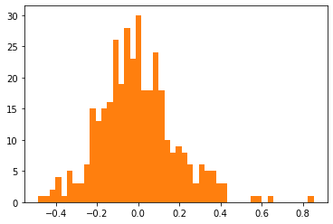

```python
data = pickle.load(open('C:/Users/yanga/Desktop/UT/CSCC11/Final/MVIX.pkl', "rb"))
logreturn = np.log(data.values[1:]/data.values[0:-1])

N = 359 #number of logreturn data
M = 48 #number of bins of histogram
n = plt.hist(logreturn, bins = M, density = False)[0] #counts in each bin
bj = plt.hist(logreturn, bins = M, density = False)[1] #edges of each bin
phat = n/N #observed proportion of each bin
```

Setting up the parameters of Genetic Algoritm:

```python
algorithm_param = {'max_num_iteration': 250,\
                   'population_size':50,\
                   'mutation_probability':0.1,\
                   'elit_ratio': 0.01,\
                   'crossover_probability': 0.5,\
                   'parents_portion': 0.3,\
                   'crossover_type':'uniform',\
                   'max_iteration_without_improv':None}
```

P value test of ChiSquare distribution is performed in order to understand how many regimes exists in the stock market.

Here two functions are used to find optimal parameters and objective value

**The objfunc** is used to find optimal parameters that minimizes the negative log return with relaxed constraints by lagrangian multipliers.Which will be forwarded to the Genetic Algorithm

**calc_obj** is used to solve for an optimal solution of the objective function given a set of parameters

```python
 def objfunc(parameter):
    '''calculate negative loglikelihood with lagrangian multiplier

    '''
    theta = parameter[0:-1]
    K = int(len(theta)/3) #calculate number of regimes
    ld= parameter[-1]
    theta = np.reshape(theta, (K, 3)) #reshape parameters into theta matrix
    obj = 0
    lagrangian = ld*abs((np.sum(theta[:, 2]) - 1))
    for j in range(M):
            pj = 0
            for k in range(K):
                mean = theta[k, 0]
                var = theta[k, 1]
                pi = theta[k, 2]
                cdf = NormalDist(mu = mean, sigma = var).cdf(bj[j+1]) - NormalDist(mu = mean, sigma = var).cdf(bj[j])
                pj += pi*cdf

            if (phat[j] > 0.0 and pj > 0.0):
                obj += phat[j]*np.log(pj/ phat[j])



    total = (-2)*N*obj + lagrangian
    return total


def calc_obj(parameter):
    '''
    calculate negative loglikelihood only
    '''
    theta = parameter
    K = int(len(theta)/3)
    theta = np.reshape(theta, (K, 3))
    obj = 0
    for j in range(M):
            pj = 0
            for k in range(K):
                mean = theta[k, 0]
                var = theta[k, 1]
                pi = theta[k, 2]
                cdf = NormalDist(mu = mean, sigma = var).cdf(bj[j+1]) - NormalDist(mu = mean, sigma = var).cdf(bj[j])
                pj += pi*cdf

            if (phat[j] > 0.0 and pj > 0.0):
                obj += phat[j]*np.log(pj / phat[j])

    total = (-2)*N*obj
    return total
```

There are 5 hypothesis in total. Each stating that there are 1, 2, 3, 4 or 5 regimes that exists in the stock market.

By solving for optimal parameters using Genetic Algorithm, and calculating the ChiSquare value of each hypothesis, P-value test can be used to determine how many regimes are present in the stock market

For the hypothesis stating there is only 1 regime in the stock market:

```
 The best solution found:
 [-7.55340150e-04  1.89031291e-01  9.99479654e-01  8.75165794e+02]

 Objective function:
 64.1699312524424
```

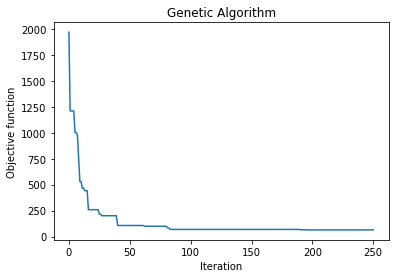

```
63.714542590979526
```

```python
regime1 = 1
varbound1 = np.array([[-1,1], [0.001,2],[0.05,1],
                      [0, 1e6]])
model1 = GeneticAlgorithm(function=objfunc, dimension= (3*regime1)+1,\
               variable_type='real',\
               variable_boundaries=varbound1,
               algorithm_parameters=algorithm_param)

model1.run()
calc_obj(model1.output_dict['variable'][0:-1])
```

For the hypothesis stating there are 2 regimes in the stock market:

```
 The best solution found:
 [1.14479393e-01 2.90208291e-01 1.04620481e-01 2.13556381e-02
 1.68063779e-01 8.96638833e-01 1.25078318e+04]

 Objective function:
 77.38015834956944
```

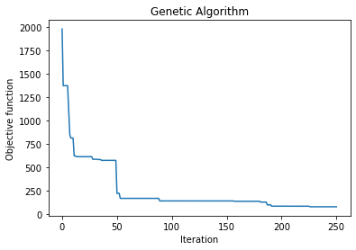

```
61.62887672911759
```

```python
regime2 = 2
varbound2 = np.array([[-3,3], [0.01,2],[0.05,1],
                      [-3,3], [0.01,2],[0.05,1],[0, 1e6]])
model2 = GeneticAlgorithm(function=objfunc, dimension= (3*regime2)+1,\
               variable_type='real',\
               variable_boundaries=varbound2,
               algorithm_parameters=algorithm_param)

model2.run()
calc_obj(model2.output_dict['variable'][0:-1])
```

For the hypothesis stating there are 3 regimes in the stock market:

```
 The best solution found:
 [-8.02065035e-02  1.64484705e-01  3.17132356e-01  3.52514238e-01
  1.64535923e-01  1.19915406e-01  3.24297198e-02  1.21431547e-01
  5.78338234e-01  2.45032922e+03]

 Objective function:
 90.34554159687403
```

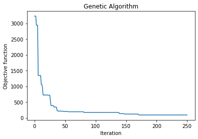

```
52.64478912537715
```

```python
regime3 = 3
varbound3 = np.array([[-3,3], [0.001,2],[0.05,1],
                      [-3,3], [0.001,2],[0.05,1],
                      [-3,3], [0.001,2],[0.05,1],
                      [0, 1e6]])

model3 = GeneticAlgorithm(function=objfunc, dimension= (3*regime3)+1,\
               variable_type='real',\
               variable_boundaries=varbound3,
               algorithm_parameters=algorithm_param)

model3.run()
calc_obj(model3.output_dict['variable'][0:-1])
```

For the hypothesis stating there are 4 regimes in the stock market:

```
 The best solution found:
 [-9.98759121e-02  1.99007991e-01  2.50998234e-01  3.83940225e-01
  2.80806864e-01  7.47058847e-02  3.00264897e-01  5.86259454e-01
  8.87323852e-02 -9.17434621e-04  1.49861160e-01  5.92467974e-01
  1.16184223e+03]

 Objective function:
 84.2171031141684
```

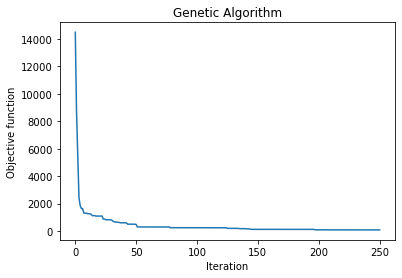

```
76.19518858608215
```

```python
regime4 = 4
varbound4 = np.array([[-3,3], [0.001,2],[0.05,0.8],
                      [-3,3], [0.001,2],[0.05,0.8],
                      [-3,3], [0.001,2],[0.05,0.8],
                      [-3,3], [0.001,2],[0.05,0.8],
                      [0, 1e6]])

model4 = GeneticAlgorithm(function=objfunc, dimension= (3*regime4)+1,\
               variable_type='real',\
               variable_boundaries=varbound4,
               algorithm_parameters=algorithm_param)

model4.run()
calc_obj(model4.output_dict['variable'][0:-1])
```

For the hypothesis stating there are 5 regimes in the stock market:

```
 The best solution found:
 [-7.66610221e-02  4.07853477e-01  9.53153252e-02 -1.93705284e-02
  2.49616155e-01  1.53232915e-01 -5.37707596e-02  1.19994374e-01
  4.87174097e-01 -9.18273903e-03  2.61269042e-01  8.30006356e-02
  1.83848496e-01  2.61853960e-01  1.80289654e-01  4.70922901e+03]

 Objective function:
 76.48126077297772
```

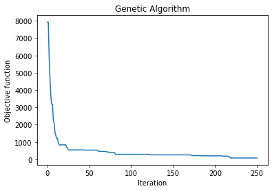

```
71.83149829063662
```

```python
regime5 = 5
varbound5 = np.array([[-3,3], [0.001,2],[0.05,0.8],
                      [-3,3], [0.001,2],[0.05,0.8],
                      [-3,3], [0.001,2],[0.05,0.8],
                      [-3,3], [0.001,2],[0.05,0.8],
                      [-3,3], [0.001,2],[0.05,0.8],
                      [0, 1e6]])

model5 = GeneticAlgorithm(function=objfunc, dimension= (3*regime5)+1,\
               variable_type='real',\
               variable_boundaries=varbound5,
               algorithm_parameters=algorithm_param)

model5.run()
calc_obj(model5.output_dict['variable'][0:-1])
```

*Choosing the number of regimes:*

Directly by looking at the Chisquare values, the hypothesis of 3 regimes yields lowest Chisquare value.

After forwarding the objective values and corresponding degree of freedom to the P-value test, using an online calculator, only the hypothesis of 3 regimes presented in the stock market passed the P-value test

Therefore the optimal number of regimes is set as **3** for the rest of the report

```python
def sort_theta(parameter, K):
    '''
    A helper function that sorts the parameters
    '''
    theta = np.reshape(parameter, (K, 3))
    return theta
```

The corresponding parameters are presented below in the format of $$\begin{bmatrix} \mu_1\ & \sigma_1\ & \pi_1\ \\ \mu_2\ & \sigma_2\ & \pi_2\ \\ \mu_3\ & \sigma_3\ & \pi_3\ \end{bmatrix}$$

```python
opttheta = sort_theta(model3.output_dict['variable'][0:-1], 3)
opttheta
```

```
array([[-0.0802065 ,  0.16448471,  0.31713236],
       [ 0.35251424,  0.16453592,  0.11991541],
       [ 0.03242972,  0.12143155,  0.57833823]])
```

### Identifying dominant regime

Now to identify exactly which regime is adopted at each month, the probability of adopting each regime at a given month is calculated and the regime with greatest probability is then identified as the dominant regime at that specific month.

The probability density function will be used to identify the dominant regime at a given month.

$\large P (\large S_t = i | x_t ; \theta ) = \frac{f(x_t ; \theta_i)}{f(x_t ; \theta)}$

The maximum conditional probability reveals the dominant regime

```python
def totalprob(xt, theta):
    ''' A helper function that calculates the total pdf of regimes at time Xt
    '''
    p= 0
    k = theta.shape[0]
    for i in range(k):
        mean = theta[i ,0]
        var = theta[i,1]
        pi = theta[i,2]
        pdf = NormalDist(mu = mean, sigma = var).pdf(xt)
        p += pi*pdf

    return p





def mcp(xt, theta, k):
    '''
    Finding the dominant regime at each month
    '''
    pmat = np.zeros([N,k])
    regime = np.zeros(N)
    for i in range(N):
        total = totalprob(xt[i], theta)
        for j in range(k):
            mean = theta[j, 0]
            var = theta[j, 1]
            pi = theta[j, 2]
            pdf = NormalDist(mu = mean, sigma = var).pdf(xt[i])
            pmat[i,j] = (pi*pdf)/total

        regime[i] = np.argmax(pmat[i])
    return regime
```

Below are the regimes for each given months from the given data

```python
mcp = mcp(logreturn, opttheta, 3)
mcp
```

```
array([0., 2., 2., 2., 2., 1., 1., 2., 2., 0., 2., 0., 2., 0., 2., 2., 2.,
       0., 2., 2., 2., 2., 2., 2., 2., 2., 2., 2., 2., 2., 2., 2., 2., 0.,
       2., 2., 2., 2., 2., 2., 0., 2., 2., 2., 2., 2., 0., 2., 1., 1., 0.,
       2., 2., 0., 2., 2., 2., 2., 0., 2., 2., 2., 2., 2., 2., 2., 0., 2.,
       2., 0., 2., 2., 1., 2., 0., 2., 0., 1., 2., 2., 2., 2., 2., 2., 2.,
       2., 2., 2., 2., 2., 2., 2., 1., 0., 2., 2., 0., 2., 2., 2., 2., 2.,
       1., 2., 0., 2., 2., 2., 2., 0., 2., 2., 0., 2., 2., 2., 2., 2., 2.,
       2., 2., 2., 2., 2., 0., 2., 0., 2., 2., 2., 2., 0., 2., 2., 2., 2.,
       0., 2., 2., 2., 2., 0., 2., 2., 2., 0., 2., 2., 2., 2., 2., 2., 0.,
       2., 2., 2., 2., 2., 0., 2., 2., 2., 2., 2., 0., 2., 2., 2., 2., 2.,
       2., 2., 2., 2., 2., 0., 2., 0., 2., 2., 2., 2., 2., 0., 2., 2., 2.,
       2., 2., 0., 2., 2., 2., 2., 2., 1., 0., 2., 0., 2., 2., 2., 2., 2.,
       1., 2., 2., 2., 2., 1., 2., 0., 2., 2., 2., 2., 2., 2., 0., 0., 1.,
       2., 2., 1., 1., 2., 0., 2., 2., 2., 0., 0., 2., 2., 2., 2., 2., 0.,
       2., 2., 0., 2., 2., 1., 2., 0., 2., 2., 2., 2., 0., 2., 2., 2., 0.,
       2., 2., 1., 2., 1., 0., 2., 0., 0., 2., 0., 2., 1., 0., 2., 2., 2.,
       2., 0., 2., 0., 2., 0., 2., 2., 2., 0., 2., 2., 0., 2., 2., 1., 0.,
       2., 2., 0., 2., 1., 0., 1., 0., 2., 1., 2., 0., 2., 2., 2., 1., 0.,
       1., 0., 0., 2., 2., 2., 2., 0., 2., 2., 2., 0., 2., 2., 2., 0., 2.,
       0., 2., 2., 2., 2., 2., 2., 2., 2., 2., 2., 2., 2., 1., 2., 0., 2.,
       2., 0., 2., 2., 1., 0., 1., 0., 2., 2., 2., 1., 0., 2., 2., 0., 0.,
       2., 2.])
```

*Transition Matrix*

A regime transition matrix is also constructed which states the probability of switching from one regime at a given month to another regime in the next month.

```python
def transition(mcp):
    '''
    construct a transition matrix given the regimes at each month
    '''
    total = np.zeros(3) #total number of each regime occurance
    transit = np.zeros([3,3])
    for i in range(N - 1): #can only have N-1 since t+1 unknown for the last term
        if mcp[i] == 0:
            total[0] += 1 #calculate total number of occurance of regime 0
            if mcp[i+1] == 0: #calculate occurance of regimes at Xt+1
                transit[0,0] += 1
            elif mcp[i+1] == 1:
                transit[0,1] += 1
            elif mcp[i+1] == 2:
                transit[0,2] += 1

        elif mcp[i] == 1:
            total[1]+= 1
            if mcp[i+1] == 0:
                transit[1,0] += 1
            elif mcp[i+1] == 1:
                transit[1,1] += 1
            elif mcp[i+1] == 2:
                transit[1,2] += 1

        elif mcp[i] == 2:
            total[2] += 1
            if mcp[i+1] == 0:
                transit[2,0] += 1
            elif mcp[i+1] == 1:
                transit[2,1] += 1
            elif mcp[i+1] == 2:
                transit[2,2] += 1

    for i in range(3):
        for j in range(3):
            transit[i,j] = transit[i,j]/total[i]
    return transit
```

The transition matrix based on the given dataset is below:

```python
transition(mcp)
```

```
array([[0.06666667, 0.06666667, 0.86666667],
       [0.46428571, 0.10714286, 0.42857143],
       [0.21960784, 0.07843137, 0.70196078]])
```

## Forecasting fear index

Now, after having a transtition matrix, we can assume that given the dominant regime/fear index of a given month we can predict future fear index. To varify this assumption, a few regression models will be used to fit the monthly EMV index, which are category-specific indices that identifies potential economic, financial factors that can trigger fluctuation and regime switches in stock market.

The regression models that are selected are OLS regression, Ridge regression, Lasso Regression and Elastic Net Regression. They will be fit to the data and their performance of predicting VIX index will be evaluated. An relatively optimal model will be chosen.

*Setting up data and models*

The EMV data along with the regression models will be loaded in:

```python
EMVdata = pickle.load(open('C:/Users/yanga/Desktop/UT/CSCC11/Final/MEMV-1.pkl', "rb"))
emvdata = np.array(EMVdata)
memv = emvdata[:,0:-1]
vixdata = np.array(emvdata[:,-1])
```

First, each model will be evaluated based on their cross-validation performance, 5-fold cross-validation will be used since our dataset size is not very large.

```python
lmols =  LinearRegression()
lmlasso = Lasso()
lmridge = Ridge()
lmenet = ElasticNet()
olscv =  cross_val_score(lmols, X = memv, y = vixdata, cv=5, scoring = 'neg_mean_squared_error')
lassocv =  cross_val_score(lmlasso, X = memv, y = vixdata, cv=5, scoring = 'neg_mean_squared_error')
ridgecv =  cross_val_score(lmridge, X = memv, y = vixdata, cv=5, scoring = 'neg_mean_squared_error')
enetcv =  cross_val_score(lmenet, X = memv, y = vixdata, cv=5, scoring = 'neg_mean_squared_error')
```

By comparing the mean value of negative mean square error score from 5 cross-validations of each regression model, an relatively optimal model for our dataset can be selected.

```python
np.mean(olscv)
```

```
-164.12715605370823
```

```python
np.mean(lassocv)
```

```
-31.869922090981323
```

```python
np.mean(ridgecv)
```

```
-159.49830957986075
```

```python
np.mean(enetcv)
```

```
-32.67583538403338
```

The score of LASSO regression model and Elastic Net regression model are close, therefore both can be selected to enter the next phase of performance evaluation, which is comparing their adjusted $R^2$ score.

The following process fits the data to each model and then their $R^2$ score is returned. By specifying number of data points and number of covariates, their adjusted $R^2$ score is calculated.

```python
lasso = LassoCV(cv = 5).fit(X = memv, y = vixdata)
elasticnet = ElasticNetCV(cv = 5).fit(X = memv, y = vixdata)
```

```python
lasso_r2 = lasso.score(X = memv, y = vixdata)
elastic_r2 = elasticnet.score(X = memv, y = vixdata)
```

```python
n_emv = 382
p_emv = 45
```

```python
adjusted_lasso_r2 = 1 -((n_emv -1)/(n_emv - p_emv - 1))*(1- lasso_r2)
adjusted_lasso_r2
```

```
0.46440849027029607
```

```python
adjusted_enet_r2 = 1 -((n_emv -1)/(n_emv - p_emv - 1))*(1- elastic_r2)
adjusted_enet_r2
```

```
0.4680075970217975
```

The Elastic Net regression has a higher adjusted $R^2$ score, so it will be the optimal model.

However, by looking at the adjusted $R^2$ score, it is clear that there are redundant covariates that aren't very helpful in the prediction of fear index. Which means that not all economic or political factors provided in the EMV affects the fluctuation.

# Summary and discussion

The optimal hypothesis is that there are 3 market regimes that exist in the stock market. By fitting a regression model, it is possible to

some extent that future regime switches and stock market movements can be predicted given informations at a current time. However the fitted

model may not be perfect, since the given data is limited in number. Forecasting the fear index is crucial to being successful in stock market

investments , since the fear index is related to economic, financial, political and many other social factors. Observing events in the society

can help investors construct the stretagies that prevents future loss or benefits future gains. The regression model fitted in this report is

not close to perfect, its performance score is not high enough, therefore the factors that actually are useful in model estimation should be

further testified and more data should be used to improve accuracy.

# References

Elumalai, G. (2019, November 19). Pros and cons of common machine learning algorithms. Medium. Retrieved December 21, 2021, from https://medium.com/@gokul.elumalai/pros-and-cons-of-common-machine-learning-algorithms-45e05423264f

Lasso vs Ridge vs elastic net: ML. GeeksforGeeks. (2020, March 12). Retrieved December 21, 2021, from https://www.geeksforgeeks.org/lasso-vs-ridge-vs-elastic-net-ml/

Emmert-Streib, F., & Dehmer, M. (n.d.). Review of Evaluation of Regression Models: Model Assessment, Model Selection and Generalization Error.